# Introducción a la ciencia de datos

Análisis de ciencia de datos, Gpo 101 - FJ 2026

Author

Dr. Javier E. Garrido Guillén

# Proyecto end-to-end de ciencia de datos

## La metodología CRISP-DM

- **Cross-Industry Standard Process for Data Mining**: Proceso basado en las mejores prácticas que busca maximizar la probabilidad de éxito de un proyecto de ciencia de datos.

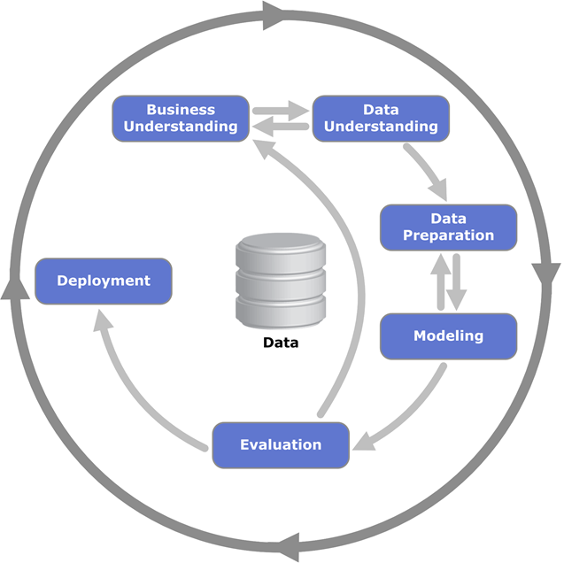

## Ejemplo: ¿Podemos salvar a Su Casita?

> Hace años existía una empresa hipotecaria llamada Su Casita. En 2013, tras dos años de agonía, [Su Casita quebró](https://www.eleconomista.com.mx/sectorfinanciero/Su-Casita-recibe-notificacion-de-sentencia-de-quiebra-20130103-0129.html). Supongamos que en ese momento, la empresa pudo salir a flote si invertía en propiedades en Sacramento, California en Estados Unidos. Para ello, es necesario obtener los precios de las viviendas y determinar si una inversión en esa zona permitiría hacer frente a las obligaciones financieras de la empresa.

[figure not shown]

## Ejemplo: ¿Podemos salvar a Su Casita?

🧠 Lo que sabemos:

- Invertirán en propiedades en Sacramento, California, Estados Unidos.
- Quieren usar un modelo para estimar los precios de las viviendas.
- El modelo alimentará otro sistema que decidirá si invertir o no. Dicho sistema requiere precios numéricos, no categorías.
- Actualmente los precios se estiman manualmente por personas expertas mediante reglas complejas.
- La empresa solo cuenta con información histórica.
- Cuentan con presupuesto limitado.
- La fecha límite para pagar a los acreedores es en 175 días.

## Entendimiento del negocio

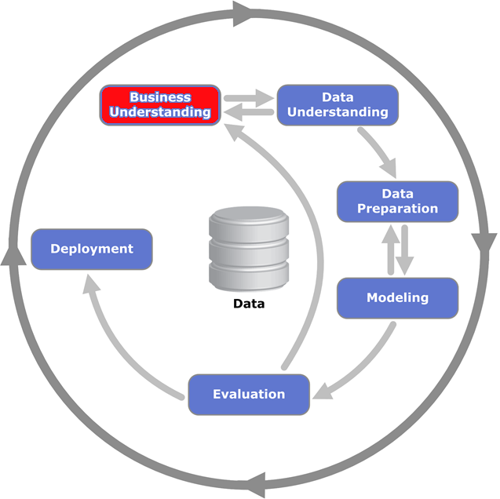

- Identificamos las necesidades del negocio (clientx) ➡️ Preguntas o hipótesis.
- Clara especificación del objetivo del negocio.
- Valoramos la viabilidad del proyecto y discutimos alternativas.
- Realizamos un plan para encontrar tal conocimiento: Especificamos responsabilidades y presupuestos.

## Su Casita: Entendimiento del negocio

✅ Vamos a utilizar como guía el [checklist de un proyecto de ciencia de datos](https://experiencia21.tec.mx/courses/645890/files/267871181?module_item_id=41106260&fd_cookie_set=1) que se encuentra en Canvas, el cual contiene los aspectos más importantes que debemos procurar cubrir.

- ¿Cuál es el objetivo específico del negocio?
- ¿Cómo Su Casita planea usar y beneficiarse del modelo?
- ¿Hay alternativas disponibles o existe experiencia humana disponible actualmente?
- ¿Existe un flujo continuo de datos o solo datos históricos?
- ¿Cómo sabremos si el proyecto es exitoso?
- ¿Tenemos que hacer algún supuesto?

## Entendimiento de los datos

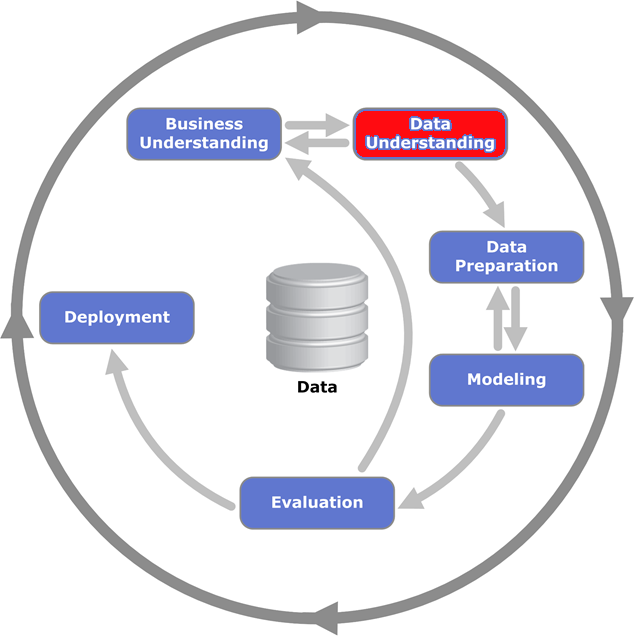

- Match perfecto entre el problema del negocio y los datos que se utilizarán para abordarlo.
- Tenemos comunicación exhaustiva con el negocio.
- Conocemos las fuentes de información, cómo está estructurada y qué significa.
- Valoramos si esta información cubrirá las demandas del negocio.
- Identificamos los factores de riesgo, los alcances y limitaciones de la información.

## Data frame

- Estructura de datos más común con la que trabajamos.
- Colección de observaciones en forma tabular.

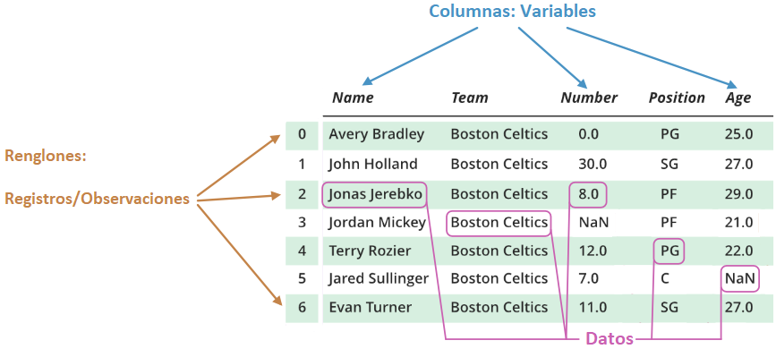

GeeksforGeeks

## ¿Por qué un data frame?

- Podemos representar los datos en forma matricial.

$$\begin{align*} \boldsymbol{\mathcal{D}} = \begin{pmatrix}
d_{11} & d_{12} & \dots & d_{1m}\\ d_{21} &
d_{22} & \dots & d_{2m}\\ \vdots & \vdots &
\ddots & \vdots\\ d_{n1} & d_{n2} & \dots &
d_{nm} \end{pmatrix} \end{align*}$$

## Su Casita: Entendimiento de los datos

- Su Casita nos proporcionó los datos de un censo que se realizó hace algunos años.
- El archivo [sacramento.csv](https://experiencia21.tec.mx/courses/645890/files/267871208?module_item_id=41106262) en Canvas contiene la información que nos compartió la empresa.

✏️ Crea una carpeta de trabajo para el proyecto.

- Un template básico para un proyecto de ciencia de datos incluye crear carpetas de trabajo para guardar archivos específicos, por ejemplo, los datos, scripts, reportes, etc.

✏️ Dentro de la carpeta de trabajo de tu proyecto crea al menos las carpetas de datos, notebooks y scripts.

## Su Casita: Espacio de trabajo

- Tu carpeta de trabajo debe verse similar a esto.

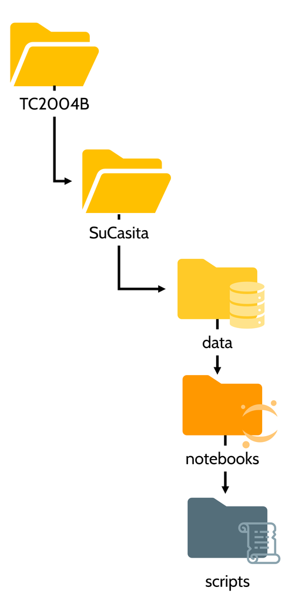

## Su Casita: Espacio de trabajo

✏️ Desde Visual Studio Code, guarda este espacio de trabajo como un archivo `.code-workspace`.

✏️ Descarga el archivo [`requirements.txt`](https://experiencia21.tec.mx/courses/645890/files/267871233?module_item_id=41106264) de Canvas el cual contiene los módulos básicos que utilizaremos durante el curso.

✏️ Añade este archivo a tu carpeta de trabajo.

✏️ Inicializa un nuevo entorno virtual de Python que contenga estos módulos.

## Su Casita: Entendimiento de los datos

✏️ Abre un nuevo notebook de Quarto (o Jupyter) y guárdalo en la carpeta `notebooks`.

✏️ En el YAML reemplaza el formato del documento por el siguiente código.

```latex
format:
    html:
        output-file: "Proyecto Su Casita"
        toc: true
        html-math-method: katex
        embed-resources: true
        self-contained-math: true
        df-print: kable
```

✏️ Importa los módulos que utilizaremos.

```python
import pandas as pd
import numpy as np
import matplotlib.pyplot as plt
import seaborn as sns
```

## Su Casita: Entendimiento de los datos

✏️ Carga el archivo de datos y visualiza las primeras observaciones.

```python
data = __________
data.__________
```

|  | city | zip | beds | baths | sqft | type | price | latitude | longitude |
| --- | --- | --- | --- | --- | --- | --- | --- | --- | --- |
| 0 | SACRAMENTO | z95838 | 2 | 1.0 | 836 | Residential | 59222 | 38.631913 | -121.434879 |
| 1 | SACRAMENTO | z95823 | 3 | 1.0 | 1167 | Residential | 68212 | 38.478902 | -121.431028 |
| 2 | SACRAMENTO | z95815 | 2 | 1.0 | 796 | Residential | 68880 | 38.618305 | -121.443839 |
| 3 | SACRAMENTO | z95815 | 2 | 1.0 | 852 | Residential | 69307 | 38.616835 | -121.439146 |
| 4 | SACRAMENTO | z95824 | 2 | 1.0 | 797 | Residential | 81900 | 38.519470 | -121.435768 |

## Su Casita: Entendimiento de los datos

**Important**

Comprueba la estructura y tipos de datos para saber si es necesario realizar alguna conversión (**data type casting**).

- Exploramos la estructura de los datos.

```python
data.__________
```

```
<class 'pandas.DataFrame'>
RangeIndex: 932 entries, 0 to 931
Data columns (total 9 columns):
 #   Column     Non-Null Count  Dtype
---  ------     --------------  -----
 0   city       932 non-null    str
 1   zip        932 non-null    str
 2   beds       932 non-null    int64
 3   baths      932 non-null    float64
 4   sqft       932 non-null    int64
 5   type       932 non-null    str
 6   price      932 non-null    int64
 7   latitude   932 non-null    float64
 8   longitude  932 non-null    float64
dtypes: float64(3), int64(3), str(3)
memory usage: 65.7 KB
```

## Su Casita: Entendimiento de los datos

- Las variables categóricas las podemos explorar a través de **tablas de frecuencia** o **tablas de contingencia**.
- Revisamos el número de propiedades de cada tipo.

```python
data[__________].__________
```

| type | count |
| --- | --- |
| Residential | 866 |
| Condo | 53 |
| Multi_Family | 13 |

## Su Casita: Entendimiento de los datos

- Podemos combinar dos variables categóricas usando la función `crosstab()` de `pandas`, por ejemplo, para visualizar el número de tipos de vivienda por código postal.

```python
pd.__________(__________, __________)
```

| type zip | Condo | Multi_Family | Residential |
| --- | --- | --- | --- |
| z95603 | 1 | 1 | 3 |
| z95608 | 3 | 0 | 17 |
| z95610 | 0 | 1 | 6 |
| z95614 | 0 | 0 | 1 |
| z95619 | 0 | 0 | 1 |
| ... | ... | ... | ... |
| z95838 | 0 | 0 | 37 |
| z95841 | 3 | 0 | 4 |
| z95842 | 5 | 1 | 16 |
| z95843 | 1 | 0 | 32 |
| z95864 | 0 | 0 | 5 |

68 rows × 3 columns

## Su Casita: Entendimiento de los datos

- Las variables numéricas las podemos explorar con estadísticas básicas.

```python
data.__________
```

|  | beds | baths | sqft | price | latitude | longitude |
| --- | --- | --- | --- | --- | --- | --- |
| count | 932.000000 | 932.000000 | 932.000000 | 932.000000 | 932.000000 | 932.000000 |
| mean | 3.275751 | 2.053112 | 1680.318670 | 246661.583691 | 38.592980 | -121.360288 |
| std | 0.887998 | 0.722599 | 726.266383 | 131126.862021 | 0.134159 | 0.140178 |
| min | 1.000000 | 1.000000 | 484.000000 | 30000.000000 | 38.241514 | -121.551704 |
| 25% | 3.000000 | 2.000000 | 1166.750000 | 156000.000000 | 38.478436 | -121.449257 |
| 50% | 3.000000 | 2.000000 | 1470.000000 | 220000.000000 | 38.619343 | -121.382474 |
| 75% | 4.000000 | 2.000000 | 1953.500000 | 305000.000000 | 38.686063 | -121.308444 |
| max | 8.000000 | 5.000000 | 4878.000000 | 884790.000000 | 39.020808 | -120.597599 |

Antes de esto deberíamos tratar los datos para ver cualquier tipo de inconsistencia, estandarizar las variables categóricas y eliminar duplicados.

## Training, validation y test set

- Comprobar el desempeño de nuestro modelo con *datos reales* ➡️ Dividir nuestro conjunto de datos.

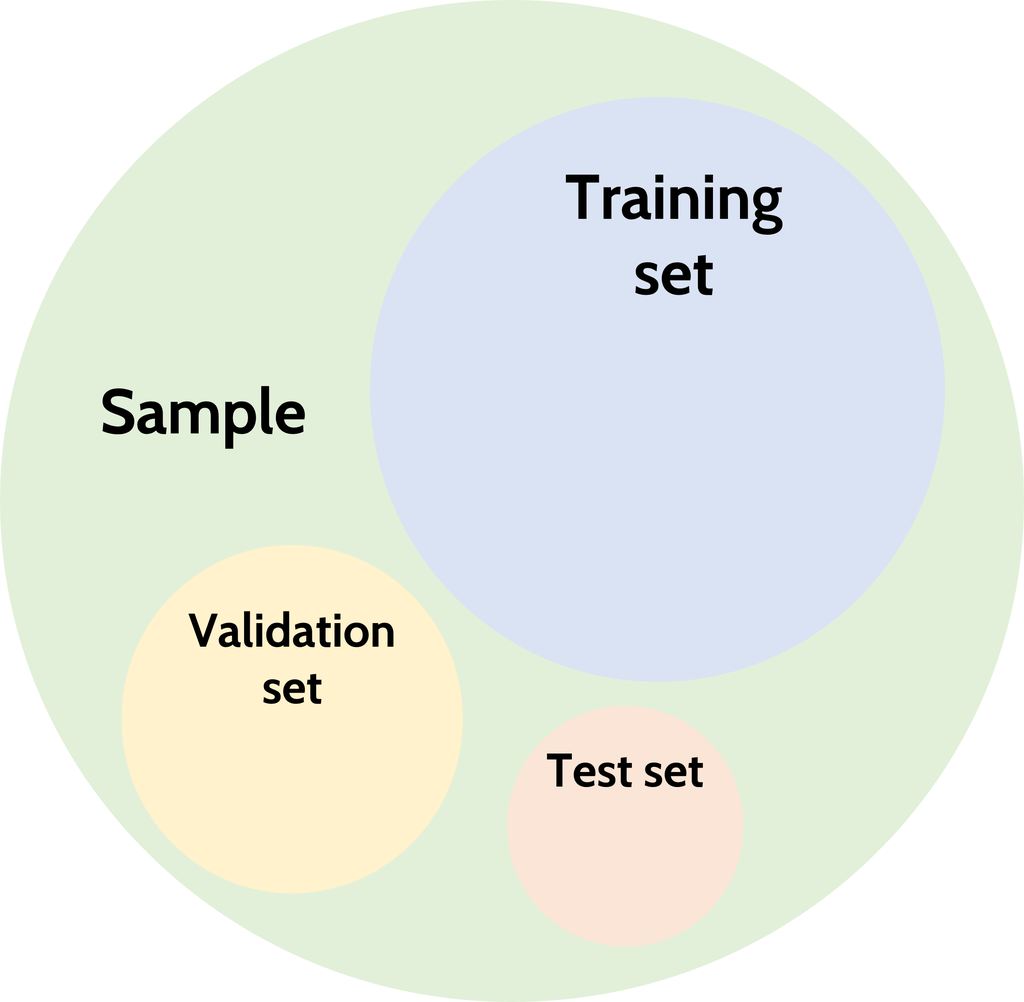

## Training, validation y test set

- **Training set**: Conjunto de datos utilizado para *entrenar* un modelo.
- **Validation set**: Conjunto de datos utilizado para *evaluar* al modelo con una **función de score** establecida.
- Si la función de score brinda una precisión mayor a la deseada, realizamos una prueba final para confirmar los resultados con el **test set**.
- En caso contrario, se ajustan los **hiperparámetros** y se repite el proceso.

## Training, validation y test set

- Optamos por dividir el conjunto de datos en dos: Training y test.
- Depende del contexto.
- Tener 3 subconjuntos puede servir como estrategia para evitar el **overfitting** (sobre-ajuste).
- Reglas de dedo: 70%-30%, 80%-20% o hasta 99%-1% en deep learning.

## Su Casita: Entendimiento de los datos

- Crearemos una función para dividir nuestros datos en training y test set.

**Tip**

- Funciones extra que ayudan en el análisis o procesamiento de datos suelen ser scripts independientes que se ejecutan antes de los notebooks principales o incluso dentro de los mismos.
- Documenta toda tu función: ¿Qué es lo que realiza? ¿Cuáles son los argumentos o parámetros de entrada? Incluidos los tipos y si existen valores por default y ¿Qué output y qué tipo de output devuelve?

## Su Casita: Entendimiento de los datos

- Nuestra función se llamará `create_train_test()` y recibirá como input los parámetros `data`, `test_ratio` y `seed`.
  - `data`: Matriz de datos.
  - `test_ratio`: Proporción de datos en el test set.
  - `seed`: Semilla para generar los números aleatorios.

**Tip**

Cuando trabajes con objetos que puedan incluir resultados aleatorios procura configurar adecuadamente la(s) semilla(s) para que tus resultados sean reproducibles y consistentes.

## Su Casita: Entendimiento de los datos

- Creamos nuestra función, como estará en un archivo independiente necesitamos cargar los módulos que usemos para que nuestra función se ejecute sin problemas.

```python
import numpy as np

def create_train_test(data, test_ratio, seed):
    '''Realiza el split de los datos en
       training y test set.

       Parámetros
       ----------
       data: pd.DataFrame
           Matriz de datos.
       test_ratio: float64
           Proporción de datos en el test set.
       seed: int64
           Semilla para generar los números aleatorios.

       Output
       ------
       pd.DataFrame, pd.DataFrame
           Un data frame con el training set
           y otro data frame con el test set.
    '''

    ## Inicializamos la semilla
    __________(seed)

    ## Creamos un arreglo con las posiciones de
    ## los datos seleccionadas de forma aleatoria
    idx = __________(__________, size = __________, replace = __________)

    ## Determinamos cuántas observaciones
    ## se incluirán en el test set
    test_size = int(__________*__________)

    ## Creamos el training y test set seleccionando
    ## los índices correspondientes que generamos
    train_set = __________[__________, :]
    test_set = __________[__________, :]

    ## Regresamos estos data frames
    ## como resultado de la función
    return train_set, test_set
```

## Su Casita: Entendimiento de los datos

- Guardamos esta función en un nuevo script de Python en la carpeta `scripts`.
- Para poder hacer uso de nuestra función en nuestro notebook utilizamos la extensión `run` de `IPython`.

```python
%run ../scripts/functions.py
```

- Podemos acceder a la información de la función con la función `help()` (o con ayuda del signo `?` antes del nombre de la función en Jupyter).

```python
help(create_train_test)
```

```
Help on function create_train_test in module __main__:

create_train_test(data, test_ratio, seed)
    Realiza el split de los datos en
    training y test set

    Parámetros
    ----------
    data: pd.DataFrame
        Matriz de datos
    test_ratio: float64
        Proporción de datos en el test set
    seed: int64
        Semilla para generar los números aleatorios

    Output
    ------
    pd.DataFrame, pd.DataFrame
        Un data frame con el training set
        y otro data frame con el test set
```

## Su Casita: Entendimiento de los datos

- Creamos nuestro training y test set.

```python
train_set, test_set = __________(__________, __________, 1234)
```

- Convenientemente, podemos usar la función `train_test_split()` de `sklearn.model_selection`.

```python
from sklearn.model_selection import train_test_split

sklearn_train, sklearn_test = train_test_split(__________,
                                               test_size = __________,
                                               random_state = 1234)
```

## La importancia del muestreo

- Existen ocasiones en que el muestreo aleatorio puede introducir sesgo.
- Una alternativa para asegurar representatividad es utilizar muestreo estratificado.
- Cada estrato asegura contar con observaciones representativas de la muestra.

**Tip**

Muy útil en problemas de clasificación donde las categorías están desbalanceadas.

## Su Casita: Entendimiento de los datos

- El precio es una variable continua ➡️ Vamos a discretizarla.
- Crearemos pequeños *bins* basados en los cuantiles para asegurar la misma proporción.
- Para discretizar una variable podemos usar la función `cut()` de `pandas`.
- Calculamos los cuantiles 0.2, 0.4, 0.6 y 0.8.

```python
price_cuts = __________
```

## Su Casita: Entendimiento de los datos

- Discretizamos el precio usando como *bins* estos cuantiles.

```python
data["price_cat"] = pd.cut(__________,
                           bins = __________,
                           labels = __________)
```

- Graficamos esta nueva variable.

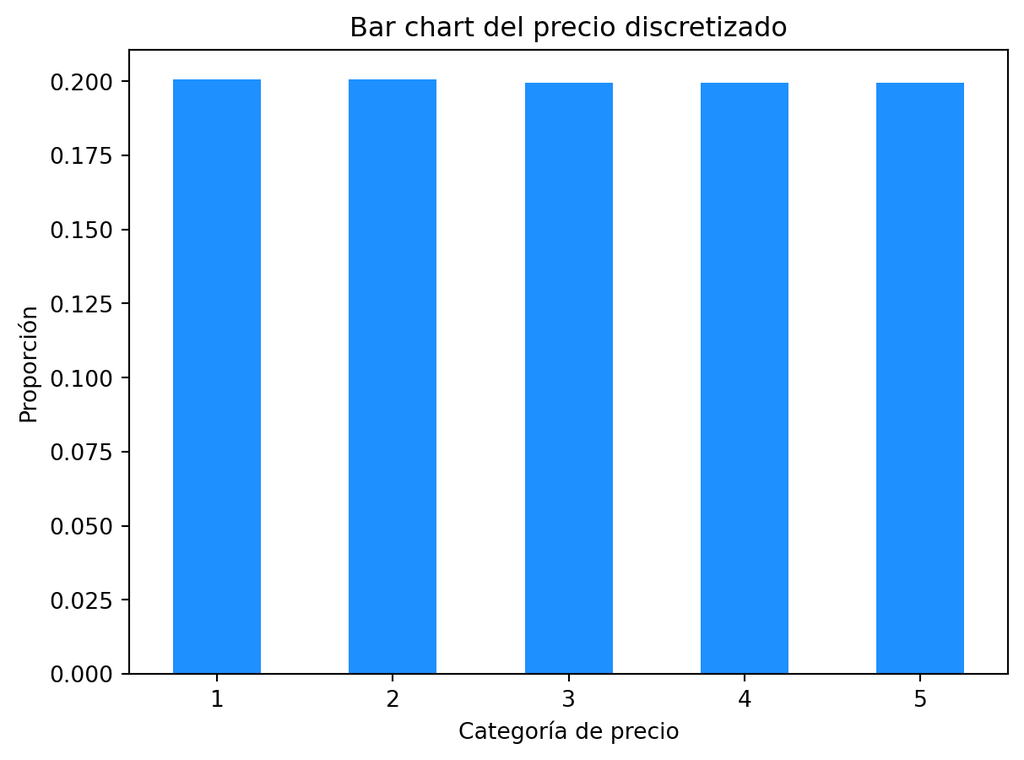

```python
data["price_cat"].value_counts(normalize = True).sort_index().plot.bar(rot = 0, color = "dodgerblue")
plt.xlabel("Categoría de precio")
plt.ylabel("Proporción")
plt.title("Bar chart del precio discretizado")
plt.show();
```

## Su Casita: Entendimiento de los datos

- Podemos dividir nuestros datos usando un muestreo estratificado respecto a esta categorización del precio con ayuda de la función `train_test_split()`.

```python
strat_train, strat_test = train_test_split(__________, test_size = __________,
                                           stratify = __________, random_state = 1234)
```

- Probamos si se respetó la proporción de viviendas por categoría en el test set.

```python
strat_test[__________].value_counts(__________).sort_values()
```

```
price_cat
1    0.2
2    0.2
3    0.2
4    0.2
5    0.2
Name: proportion, dtype: float64
```

## Su Casita: Entendimiento de los datos

- Comprobamos que obtenemos una distribución similar en el conjunto de entrenamiento y en el de prueba.

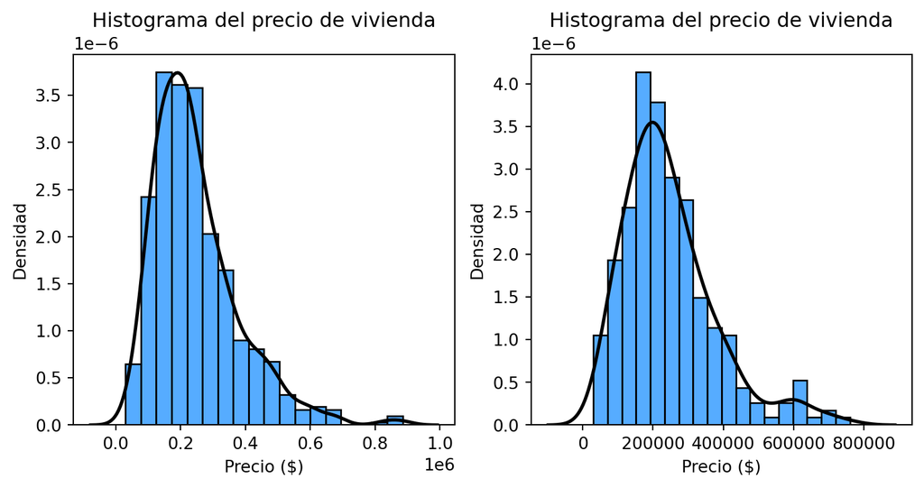

```python
fig, (ax1, ax2) = plt.subplots(1, 2, figsize = (9, 4))

## Histograma en el training set
sns.histplot(strat_train, x = "price", ax = ax1, bins = 18,
             color = "dodgerblue", stat = "density")
sns.kdeplot(strat_train["price"], ax = ax1,
            color = "black", linewidth = 2)
ax1.set_title("Histograma del precio de vivienda")
ax1.set_xlabel("Precio ($)")
ax1.set_ylabel("Densidad")

## Histograma en el test set
sns.histplot(strat_test, x = "price", ax = ax2, bins = 18,
             color = "dodgerblue", stat = "density")
sns.kdeplot(strat_test["price"], ax = ax2,
            color = "black", linewidth = 2)
ax2.set_title("Histograma del precio de vivienda")
ax2.set_xlabel("Precio ($)")
ax2.set_ylabel("Densidad")
plt.show();
```

## Su Casita: Entendimiento de los datos

- Ya no utilizaremos las categorías de precios, por lo que las eliminamos del training y test set con ayuda del método `drop()`.

```python
for set_ in (strat_train, strat_test):
    set_.drop(columns = __________, inplace = __________)
```

- Vamos a crear una copia de los datos originales para revertir los cambios que hagamos.

```python
data_train = strat_train.copy()
```

## Su Casita: Entendimiento de los datos

- Generamos una lista con los nombres de las variables categóricas y otra lista con las numéricas con ayuda del método `select_dtypes()`.

```python
categorical_vars = data_train.__________(__________).__________
numeric_vars = data_train.__________(__________).__________
```

```
Variables categóricas: Index(['city', 'zip', 'type'], dtype='str')
Variables numéricas: Index(['beds', 'baths', 'sqft', 'price', 'latitude', 'longitude'], dtype='str')
```

## Su Casita: Explorando los datos

- Visualizamos las variables numéricas por medio de histogramas y kernel plots.

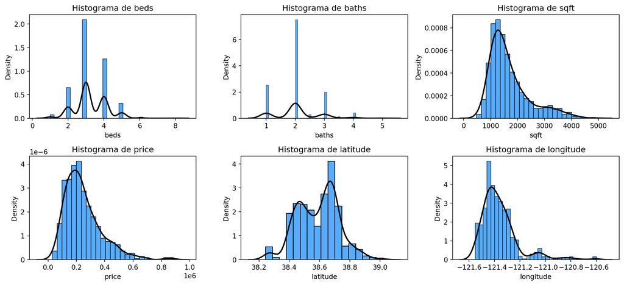

```python
fig, axes = plt.subplots(nrows = 2, ncols = 3, figsize = (13, 6))
axes = axes.flatten()
for ax, col in zip(axes, numeric_vars):
    sns.histplot(data_train[col],
                 ax = ax,
                 color = "dodgerblue",
                 stat = "density")
    sns.kdeplot(data_train[col], ax = ax, color = "black", linewidth = 2)
    ax.set_title(f"Histograma de {col}")
plt.tight_layout()
plt.show();
```

## Su Casita: Explorando los datos

- Visualizaremos las ubicaciones de las viviendas usando un scatter plot.

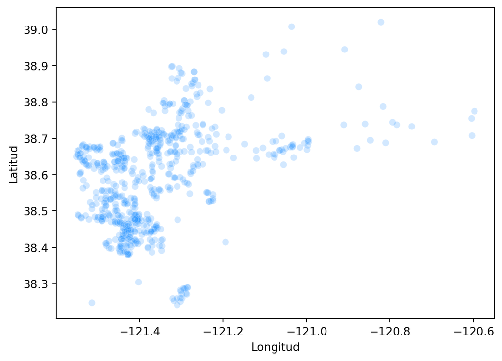

```python
sns.scatterplot(data = data_train,
                x = "longitude", y = "latitude",
                color = "dodgerblue", alpha = 0.2)
plt.xlabel("Longitud")
plt.ylabel("Latitud")
plt.show();
```

## Su Casita: Explorando los datos

- Otra opción para visualizar los datos geográficos es incluir otras variables como los pies cuadrados de la propiedad, que representaremos con el tamaño de los círculos.
- Además, representaremos el precio de la vivienda con el color de los círculos.

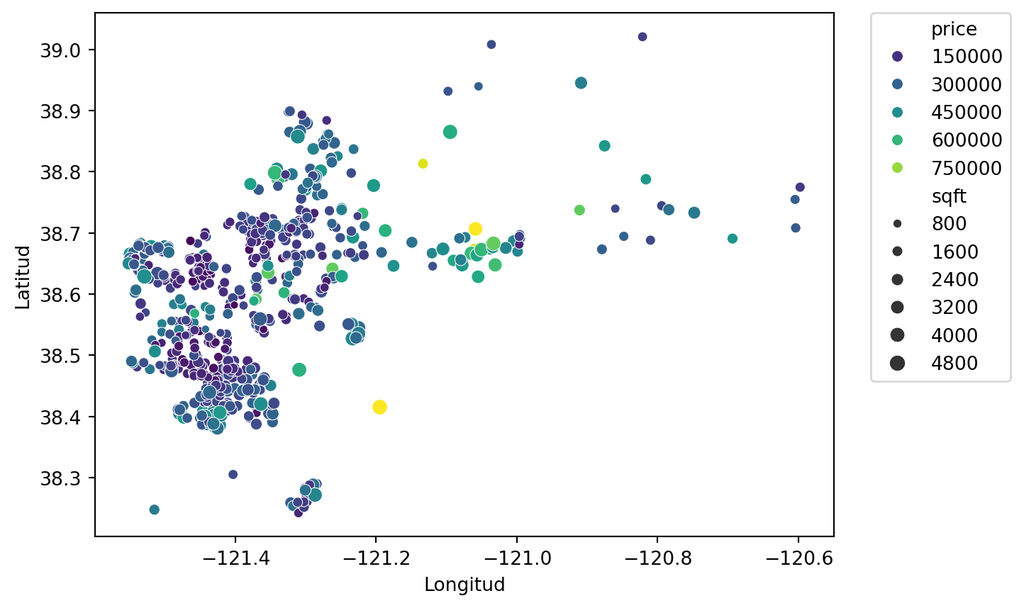

```python
sns.scatterplot(data = data_train, x = "longitude", y = "latitude",
                size = "sqft",
                hue = "price",
                palette = sns.color_palette("viridis", as_cmap = True))
plt.xlabel("Longitud")
plt.ylabel("Latitud")
plt.legend(bbox_to_anchor = (1.05, 1), loc = "upper left", borderaxespad = 0)
plt.show();
```

## Correlación

- Dos variables $x$ y $y$ están correlacionadas si un cambio en una, provoca un cambio en la otra.
- **Relación de dependencia**.
- Si aumenta la demanda de un producto, es muy probable que aumente su costo.
  - La demanda de un producto está correlacionada con el precio del producto.

## Tipos de correlación

- Tiene una dirección y una magnitud.
  - Positiva: Si una variable aumenta (disminuye), la otra también aumenta (disminuye).
  - Negativa: Si una variable aumenta, la otra disminuye y viceversa.

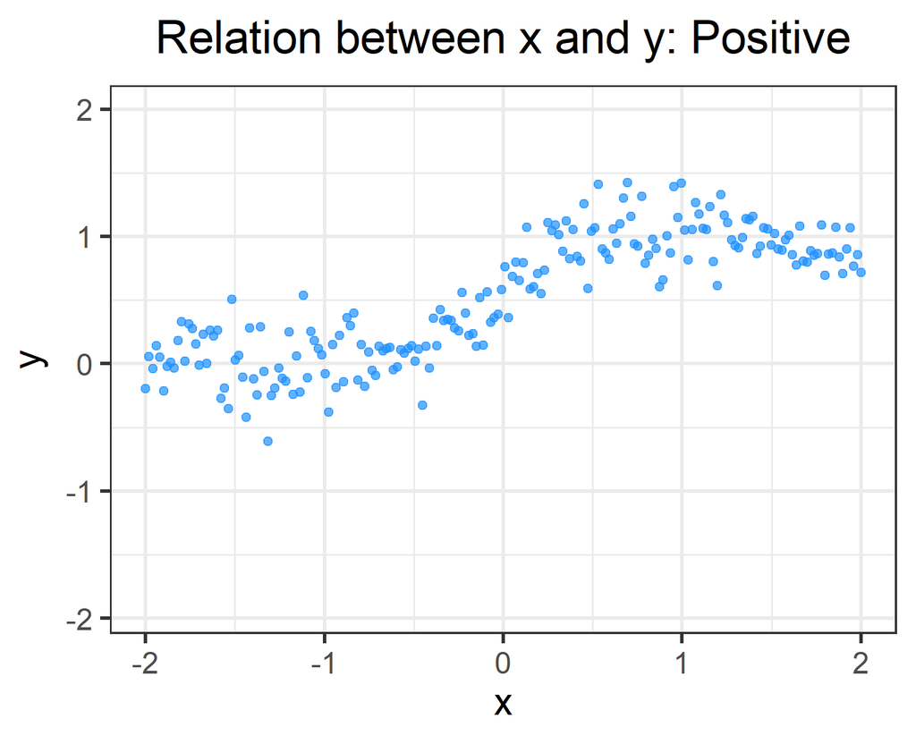

## Correlación lineal

- La relación entre dos variables se puede describir mediante una función lineal.
- **Coeficiente de correlación de Pearson**: Mide el grado de relación lineal entre dos **variables numéricas**.

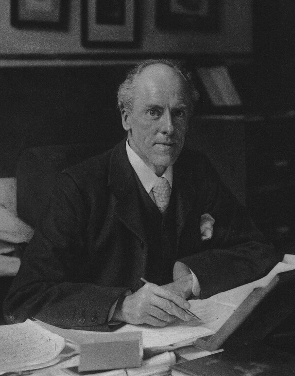

Karl Pearson

## Coeficiente de correlación de Pearson

- Si $(x_{1}, y_{1}), (x_{2}, y_{2}), \dots, (x_{n}, y_{n})$ son pares de observaciones de las variables $x$ y $y$, con medias muestrales $\bar{x}$ y $\bar{y}$, entonces el coeficiente de correlación de Pearson está dado por

$$\begin{align*} \rho &= \frac{\sum_{i = 1}^{n}(x_{i} -
\bar{x})(y_{i} - \bar{y})}{\sqrt{\sum_{i = 1}^{n}(x_{i} -
\bar{x})^{2}\sum_{j = 1}^{n}(y_{j} - \bar{y})^{2}}}\\ &=
\frac{S_{xy}}{\sqrt{S_{xx}}\sqrt{S_{yy}}} \end{align*}$$

## Coeficiente de correlación de Pearson

- $-1 \leq \rho \leq 1$.
- $-1 < \rho < 0$: Existe una relación negativa débil/fuerte entre $x$ y $y$.
- $0 < \rho < 1$: Existe una relación positiva débil/fuerte entre $x$ y $y$.
- $\rho = \pm 1$: Existe una relación positiva/negativa perfecta entre $x$ y $y$.
- $\rho = 0$: No hay relación (al menos lineal) entre $x$ y $y$.

## ¿Cómo se ve?

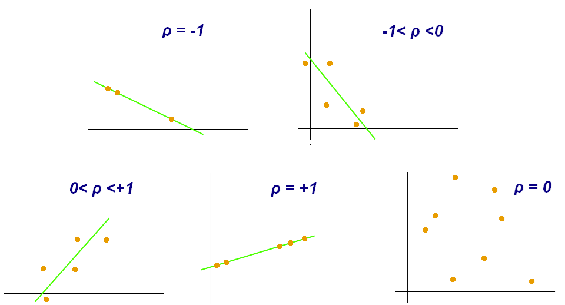

## Su Casita: Explorando los datos

- Calculamos la **matriz de correlación** usando el método `corr()`.

```python
cor_mat = __________
```

- Extraemos las correlaciones con el precio y las ordenamos en orden descendente.

```python
cor_mat[__________].__________
```

```
price        1.000000
sqft         0.753194
baths        0.575050
beds         0.435563
longitude    0.354100
latitude     0.135755
Name: price, dtype: float64
```

## Su Casita: Explorando los datos

- Mapa de calor: Forma práctica de representar la matriz de correlación.
- Redondeamos las correlaciones a dos decimales.

```python
cor_mat = round(cor_mat, 2)
```

- Creamos el layout para nuestra visualización como una matriz triangular con ayuda de las funciones `triu()` y `ones_like()` de `numpy`.

```python
mask = np.triu(np.ones_like(__________, dtype = bool))
```

## Su Casita: Explorando los datos

- Creamos un gradiente de colores con ayuda de la funcion `diverging_palette()` de `seaborn`.
- Está basada en los [colores HUSL](https://www.hsluv.org/).

```python
col = sns.diverging_palette(255, 0, as_cmap = True)
```

- Creamos el mapa de calor.

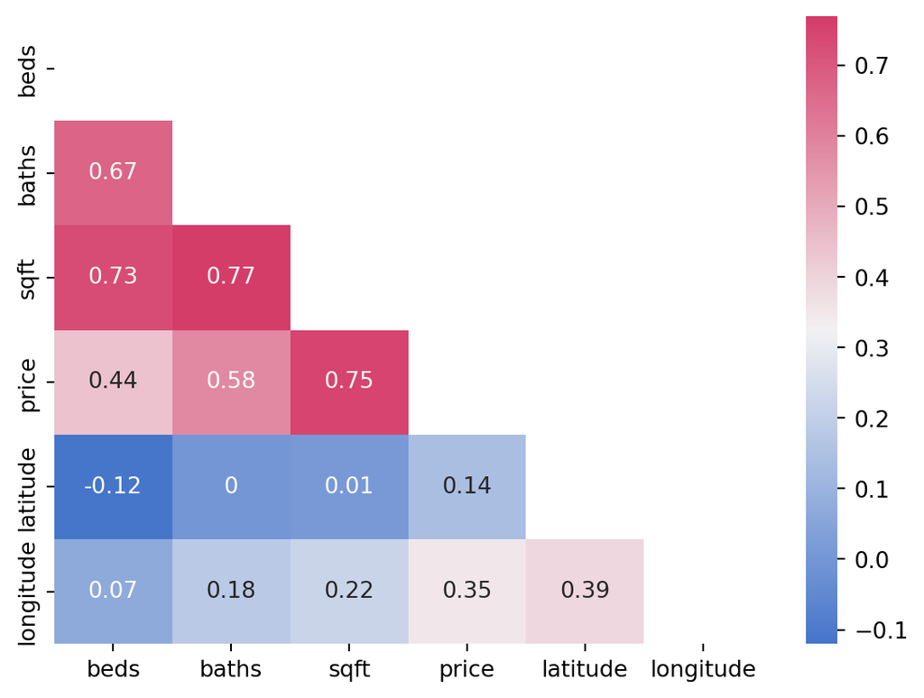

```python
sns.heatmap(cor_mat, mask = mask, annot = True, cmap = col)
plt.show();
```

## ¿Qué pasa si la correlación no es lineal?

- Correlación de Spearman: Funciones monótonas.

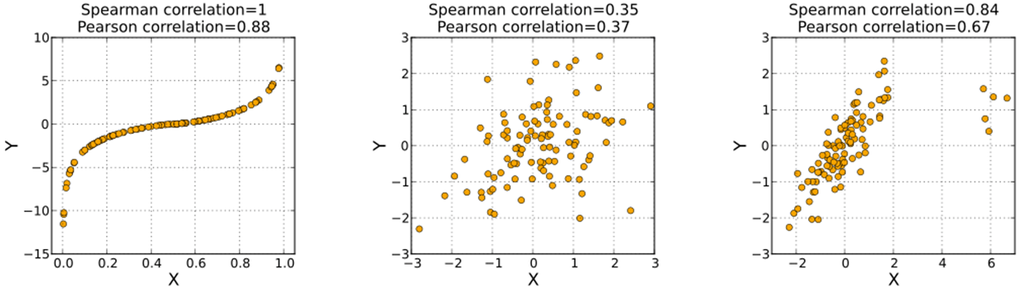

## Su Casita: Explorando los datos

- Usamos la función `spearmanr()` de `scipy.stats`.
- Extraemos los valores de la correlación usando el atributo `statistic`.

```python
from scipy.stats import spearmanr

cor_mat_spearman = spearmanr(__________).statistic
```

- Redondeamos los valores con ayuda de la función `round()` de `numpy`.

```python
cor_mat_spearman = __________
```

## Su Casita: Explorando los datos

- El objeto resultante de la función de Spearman es un arreglo, para que obtengamos una visualización similar a la de la correlación de Pearson, convertimos este objeto a un `DataFrame` de `pandas`.

```python
cor_mat_spearman = pd.DataFrame(__________, index = __________, columns = __________)
```

|  | beds | baths | sqft | price | latitude | longitude |
| --- | --- | --- | --- | --- | --- | --- |
| beds | 1.00 | 0.65 | 0.74 | 0.45 | -0.11 | 0.11 |
| baths | 0.65 | 1.00 | 0.75 | 0.57 | 0.00 | 0.18 |
| sqft | 0.74 | 0.75 | 1.00 | 0.76 | -0.02 | 0.21 |
| price | 0.45 | 0.57 | 0.76 | 1.00 | 0.11 | 0.29 |
| latitude | -0.11 | 0.00 | -0.02 | 0.11 | 1.00 | 0.41 |
| longitude | 0.11 | 0.18 | 0.21 | 0.29 | 0.41 | 1.00 |

## Su Casita: Explorando los datos

- Creamos un mapa de calor con la matriz de correlación de Spearman.

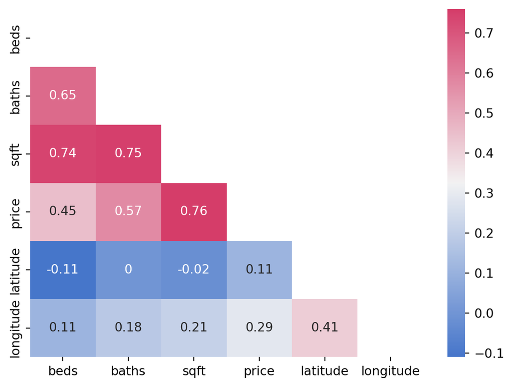

```python
mask = __________
col = __________

sns.heatmap(__________, mask = __________, annot = __________, cmap = __________)
plt.show();
```

## Footnotes

[^1]: Kalita, J. K., Bhattacharyya, D. K., & Roy, S. (2024). *Fundamentals of data science: Theory and practice*. Academic Press.